# Unboxing the blackbox: Autograd, extras with XOR

Date: June 20, 2020

This is an attempt to combine all of these components that are developed from scratch for a basic proof-of-concept ML model. We have already dealt with basic components in [this post](http://blackbox.nn.157239n.com/basics), and we have dealt with autograd in this post. Although we have dealt with the basic building blocks of Autograd already, there are still a lot of operations that track gradients that we haven't dealt with to really recreate the existing PyTorch experience.

I was halfway through implementing a basic MNIST classifier in an [extra post](http://blackbox.nn.157239n.com/autograd-extras), but the notebook is too large, grinds to a halt, and I can't iterate on it fast enough to worth the effort. So I sort of just abandoned that attempt. But a while later, I sort of wanted to make it full circle, so that it serve both as a good reference for me, and as a minimum viable proof of concept for recreating everything from scratch.

The setup now is much simpler. Instead of MNIST, we will use an even simpler problem that purely linear models can't work, which is the XOR problem. This dataset only has 4 samples divided into 2 categories:

| input | output |
| --- | --- |
| (0, 0) | 0 |
| (0, 1) | 1 |
| (1, 0) | 1 |
| (1, 1) | 0 |

And heres a visualization of it:

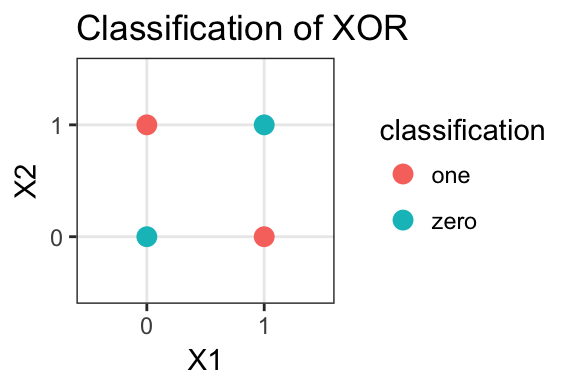

Now, I hope it's clear why linear and logistic models fail at this. There exists no line that can cleanly separate them. Let's build a model thats completely built in first:

```python
import torch
import torch.nn as nn
import numpy as np
import matplotlib.pyplot as plt
import gc
%load_ext dotmagic

from torch.utils.data import Dataset, DataLoader
import torchvision.datasets as datasets
import torchvision
import torch.optim as optim
import math
import time
```

This is the dataset itself, complying with PyTorch's way of creating Datasets:

```python
class XORDataset(Dataset):
    def __init__(self):
        self
    def __len__(self):
        return 4
    def __getitem__(self, index):
        if index == 0:
            return torch.Tensor([0., 0.]), float(0)
        elif index == 1:
            return torch.Tensor([0., 1.]), float(1)
        elif index == 2:
            return torch.Tensor([1., 0.]), float(1)
        else:
            return torch.Tensor([1., 1.]), float(0)
xorDl = DataLoader(XORDataset(), batch_size=4)
```

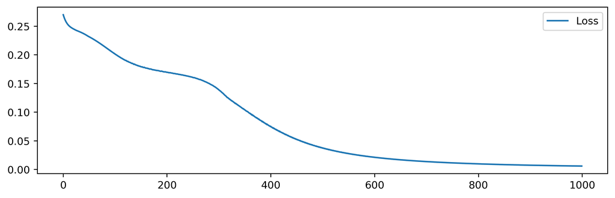

```
(tensor([[0.0655],
         [0.9536],
         [0.8807],
         [0.0556]], grad_fn=<SigmoidBackward>),
 tensor([0., 1., 1., 0.], dtype=torch.float64))
```

```python
class NN(nn.Module):
    def __init__(self):
        super().__init__()
        self.fc1 = nn.Linear(2, 4); self.fc2 = nn.Linear(4, 1)
        self.relu = nn.ReLU(); self.sigmoid = nn.Sigmoid()
        self.totalLosses = []
    def forward(self, x):
        return self.sigmoid(self.fc2(self.relu(self.fc1(x))))
    def train(self, dl, lr, epochs):
        lossFunction = nn.MSELoss(); optimizer = optim.SGD(self.parameters(), lr=lr)
        for epoch in range(epochs):
            optimizer.zero_grad(); x, y = next(iter(dl))
            loss = lossFunction(self.forward(x).squeeze(), y.float())
            loss.backward(); optimizer.step(); self.totalLosses.append(loss.item())
    def plotLosses(self, begin=0, end=0):
        plt.figure(num=None, figsize=(10, 3), dpi=350)
        if end == 0: end = len(self.totalLosses)
        plt.plot(range(len(self.totalLosses))[begin:end], self.totalLosses[begin:end])
        plt.legend(["Loss"]); plt.show()
net = NN(); net.train(xorDl, lr=0.3, epochs=1000); net.plotLosses()
x, y = next(iter(xorDl)); net(x), y
```

Looks great! The answer is pretty close to the desired output. There are several features that are different from other posts that I'd like you to notice. First, I'm using SGD, which is pretty vanilla and doesn't have smart mechanisms to control its own behavior. This is because when I used Adam, it did too good, and the error goes down too fast to compare to our model from scratch. Also, note that the learning rate is 0.3, which is quite large considering all of the experimentation in a [previous post](http://deepdive.nn.157239n.com/learning-rate), but if I set that lower, it sort of never converges, as the batch size is too small and there aren't much varied data.

Let's now take everything from the [first Autograd post](http://blackbox.nn.157239n.com/autograd) and dump it here. Note that we're using an extra `usingGrad` variable to tell our networks whether it should track gradients or not:

```python
def IdentityBackward(x1, x2, nextGrad): return (x1, None)
def ExpBackward(x1, x2, nextGrad): return (nextGrad * torch.exp(x1.data), None)
def SinBackward(x1, x2, nextGrad): return (nextGrad * torch.cos(x1.data), None)
def CosBackward(x1, x2, nextGrad): return (nextGrad * (-torch.sin(x1.data)), None)
def LogBackward(x1, x2, nextGrad): return (nextGrad * 1/x1.data, None)
def MulBackward(x1, x2, nextGrad): return (nextGrad * x2.data, nextGrad * x1.data)
def AddBackward(x1, x2, nextGrad):
    if nextGrad is None: return (None, None)
    return (nextGrad * torch.ones(*x1.shape), nextGrad * torch.ones(*x2.shape))
def SumBackward(x1, x2, nextGrad): return (nextGrad * torch.ones(*x1.shape), None)
```

```python
usingGrad=True
class Tensor:
    def __init__(self, data, grad_fn=None):
        self.data = data; self.shape = data.shape
        self.requires_grad = False; self.grad_fn = grad_fn; self.grad = None
        self.x1, self.x2 = None, None # placeholders for dependent variables
    def requires_grad_(self, requires_grad):
        self.grad_fn = IdentityBackward if requires_grad else None
        self.requires_grad = requires_grad; return self
    def __repr__(self):
        return str(self.data)
    def sum(self, dim=None):
        if dim is not None:
            if self.grad_fn:
                answer = Tensor(self.data.sum(dim=dim), grad_fn=SumBackward)
                answer.x1 = self; return answer
            else: return Tensor(self.data.sum(dim=dim))
        if self.grad_fn:
            answer = Tensor(self.data.sum(), grad_fn=SumBackward)
            answer.x1 = self; return answer
        else: return Tensor(self.data.sum())
    def __add__(self, tensor):
        if type(tensor) in [int, float]: tensor = Tensor(torch.ones(*self.shape)*tensor)
        #if self.shape != tensor.shape: raise Exception("Incompatible shapes")
        if (tensor.grad_fn or self.grad_fn) and usingGrad:
            answer = Tensor(self.data + tensor.data, grad_fn=AddBackward)
            answer.x1 = self; answer.x2 = tensor; return answer
        else: return Tensor(self.data + tensor.data)
    def __radd__(self, tensor): return self.__add__(tensor)
    def __mul__(self, tensor, grad=True):
        if type(tensor) in [int, float]: tensor = Tensor(torch.ones(*self.shape)*tensor)
        if self.shape != tensor.shape:
            raise Exception(f"Incompatible shapes: {self.shape}, {tensor.shape}")
        if (tensor.grad_fn or self.grad_fn) and usingGrad:
            answer = Tensor(self.data * tensor.data, grad_fn=MulBackward)
            answer.x1 = self; answer.x2 = tensor; return answer
        else: return Tensor(self.data * tensor.data)
    def __rmul__(self, tensor): return self.__mul__(tensor)
    def calculateGradientOfDependents(self):
        if self.grad_fn:
            #print(f"grad: {self.grad}")
            #if type(self.grad) == Tensor or type(self.grad) == torch.Tensor: print(f"grad shape: {self.grad.shape}")
            gradX1, gradX2 = self.grad_fn(self.x1, self.x2, self.grad)
            # this is the chain rule part
            if type(self.grad) != type(None):
                if type(gradX1) != type(None): self.x1.grad = gradX1
                if type(gradX2) != type(None): self.x2.grad = gradX2
                # if doesn't track gradient, then delete to free resources
                if not self.requires_grad: del self.grad; self.grad = None
            if type(self.x1) != type(None): self.x1.calculateGradientOfDependents()
            if type(self.x2) != type(None): self.x2.calculateGradientOfDependents()
    def backward(self):
        if len(self.shape) != 0:
            raise Exception(".backward() can only be called from rank 0 tensors")
        self.grad = 1; self.calculateGradientOfDependents()
        gc.collect()
class Utils:
    def __init__(self): pass
    def rand(self, *shape): return Tensor(torch.rand(shape))
    def zeros(self, *shape): return Tensor(torch.zeros(shape))
    def ones(self, *shape): return Tensor(torch.ones(shape))
    def exp(self, tensor: Tensor):
        if tensor.grad_fn:
            answer = Tensor(torch.exp(tensor.data), grad_fn=ExpBackward)
            answer.x1 = tensor; return answer
        else: return Tensor(torch.exp(tensor.data))
    def sin(self, tensor: Tensor):
        if tensor.grad_fn:
            answer = Tensor(torch.sin(tensor.data), grad_fn=SinBackward)
            answer.x1 = tensor; return answer
        else: return Tensor(torch.sin(tensor.data))
    def cos(self, tensor: Tensor):
        if tensor.grad_fn:
            answer = Tensor(torch.cos(tensor.data), grad_fn=CosBackward)
            answer.x1 = tensor; return answer
        else: return Tensor(torch.cos(tensor.data))
    def log(self, tensor: Tensor):
        if tensor.grad_fn:
            answer = Tensor(torch.log(tensor.data), grad_fn=LogBackward)
            answer.x1 = tensor; return answer
        else: return Tensor(torch.log(tensor.data))
utils = Utils()
```

```python
def MmBackward(x1, x2, nextGrad):
    if nextGrad is None: return (None, None)
    x1Grad = nextGrad @ x2.data.transpose(-2, -1)
    x2Grad = x1.data.transpose(-2, -1) @ nextGrad
    while len(x1Grad.shape) > len(x1.shape): x1Grad = x1Grad.sum(dim=0)
    while len(x2Grad.shape) > len(x2.shape): x2Grad = x2Grad.sum(dim=0)
    return (x1Grad, x2Grad)
def matmul(self, tensor):
    if tensor.grad_fn or self.grad_fn:
        answer = Tensor(self.data @ tensor.data, grad_fn=MmBackward)
        answer.x1 = self; answer.x2 = tensor; return answer
    else: return Tensor(self.data @ tensor.data)
Tensor.matmul = matmul
```

Pretty standard, and you should feel comfortable with the code above. Now, I have built more operations that track gradients, operations that I think are not fundamental to understanding how Autograd works, but is still very convenient in normal training. Now, there's a subtraction, greater than (>), unsqueeze, divide, negate and slice. For this example though, we will just use basic math, and no resizing and reshaping operations:

```python
def SubBackward(x1, x2, nextGrad):
    return (nextGrad * torch.ones(*x1.shape), nextGrad * (-torch.ones(*x2.shape)))
def sub(self, tensor, grad=True):
    if type(tensor) in [int, float]: tensor = Tensor(torch.ones(*self.shape)*tensor)
    #if self.shape != tensor.shape: raise Exception("Incompatible shapes")
    if (tensor.grad_fn or self.grad_fn) and usingGrad:
        answer = Tensor(self.data - tensor.data, grad_fn=SubBackward)
        answer.x1 = self; answer.x2 = tensor; return answer
    else: return Tensor(self.data - tensor.data)
Tensor.__sub__ = sub
def rsub(self, tensor): return self.__sub__(tensor)
Tensor.__rsub__ = rsub

def GtBackward(x1, x2, nextGrad):
    return (nextGrad * (x1.data > x2.data), nextGrad * (x2.data > x1.data))
def gt(self, tensor):
    if type(tensor) in [int, float]: tensor = Tensor(torch.ones(*self.shape)*tensor)
    if tensor.grad_fn or self.grad_fn:
        answer = Tensor(self.data - tensor.data, grad_fn=GtBackward)
        answer.x1 = self; answer.x2 = tensor; return answer
    else: return Tensor(self.data - tensor.data)
Tensor.__gt__ = gt

def UnsqueezeBackward(x1, x2, nextGrad):
    return (torch.ones(*x1.shape), None)
def unsqueeze(self, dim):
    if self.grad_fn:
        answer = Tensor(self.data.unsqueeze(dim), grad_fn=UnsqueezeBackward)
        answer.x1 = self; return answer
    else: return Tensor(self.data.unsqueeze(dim))
Tensor.unsqueeze = unsqueeze

def DivBackward(x1, x2, nextGrad):
    return (nextGrad / x2.data, -nextGrad * x1.data / (x2.data * x2.data))
def div(self, tensor):
    if type(tensor) in [int, float]:
        if len(self.shape) > 0: tensor = Tensor(torch.ones(*self.shape)*tensor)
        else: tensor = Tensor(torch.ones(1)[0]*tensor)
    if self.shape != tensor.shape:
        pass#raise Exception(f"Incompatible shapes: {self.shape}, {tensor.shape}")
    if tensor.grad_fn or self.grad_fn:
        answer = Tensor(self.data / tensor.data, grad_fn=DivBackward)
        answer.x1 = self; answer.x2 = tensor; return answer
    else: return Tensor(self.data / tensor.data)
Tensor.__truediv__ = div
def rdiv(self, tensor):
    if type(tensor) in [int, float]:
        if len(self.shape) > 0: tensor = Tensor(torch.ones(*self.shape)*tensor)
        else: tensor = Tensor(torch.ones(1)[0]*tensor)
    if self.shape != tensor.shape:
        pass#raise Exception(f"Incompatible shapes: {self.shape}, {tensor.shape}")
    if tensor.grad_fn or self.grad_fn:
        answer = Tensor(tensor.data / self.data, grad_fn=DivBackward)
        answer.x1 = tensor; answer.x2 = self; return answer
    else: return Tensor(tensor.data / self.data)
Tensor.__rtruediv__ = rdiv

def NegBackward(x1, x2, nextGrad): return (nextGrad * (-torch.ones(*x1.shape)), None)
def neg(self):
    if self.grad_fn and usingGrad:
        answer = Tensor(-self.data, grad_fn=NegBackward); answer.x1 = self; return answer
    else: return Tensor(-self.data)
Tensor.__neg__ = neg

def tlen(self): return len(self.data)
Tensor.__len__ = tlen

def Slice2dBackward(x, ranges, nextGrad):
    ranges1, ranges2 = ranges
    xGrad = torch.zeros(*x.shape)
    xGrad[ranges1, ranges2] = 1
    return (xGrad, None)
def slice2d(self, ranges1, ranges2):
    if self.grad_fn:
        answer = Tensor(self.data[ranges1, ranges2], grad_fn=Slice2dBackward)
        answer.x1 = self; answer.x2 = (ranges1, ranges2); return answer
    else: return Tensor(self.data[ranges1, ranges2])
Tensor.slice2d = slice2d
```

And here's the rest of the basic components other than Autograd:

```python
class ReLU(nn.Module):
    def __init__(self):
        super().__init__()
    def forward(self, x):
        return (x > 0) * x
class Linear(nn.Module):
    def __init__(self, input_features, output_features):
        super().__init__()
        kSqrt = math.sqrt(1/input_features)
        self.weight = (utils.rand(input_features, output_features)*2*kSqrt-kSqrt).requires_grad_(True)
        self.bias = (utils.rand(output_features)*2*kSqrt-kSqrt).requires_grad_(True)
    def forward(self, x):
        return x.matmul(self.weight) + self.bias
class Sigmoid(nn.Module):
    def __init__(self):
        super().__init__()
    def forward(self, x):
        return 1/(1+utils.exp(-x))
class MSELoss(nn.Module):
    def __init__(self):
        super().__init__()
    def forward(self, output, label):
        return ((output-label) * (output-label)).sum()
class Optimizer:
    def __init__(self, parameters, lr=0.001):
        self.parameters = list(parameters) # take the parameters out of the generator
        self.lr = lr
    def zero_grad(self):
        for param in self.parameters:
            if param.grad is not None:
                param.grad.zero_()
    def step(self):
        usingGrad=False
        for param in self.parameters:
            if param.grad != None:
                param.data = param.data - self.lr * param.grad
        usingGrad=True
```

Let's test this out:

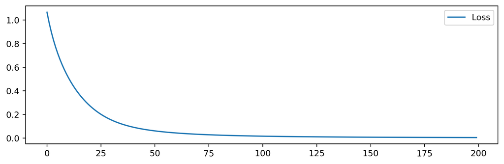

```
(tensor([[0.0419],
         [0.9601],
         [0.9785],
         [0.0188]]),
 tensor([[0.],
         [1.],
         [1.],
         [0.]]))
```

```python
x = Tensor(torch.Tensor([[0., 0.], [0., 1.], [1., 0.], [1., 1.]]))
y = Tensor(torch.Tensor([[0.], [1.], [1.], [0.]]))
class NN(nn.Module):
    def __init__(self):
        super().__init__(); self.fc1 = Linear(2, 4); self.fc2 = Linear(4, 1)
        self.relu = ReLU(); self.sigmoid = Sigmoid(); self.totalLosses = []
    def forward(self, x):
        return self.sigmoid(self.fc2(self.relu(self.fc1(x))))
    def parameters(self):
        return [self.fc1.weight, self.fc1.bias, self.fc2.weight, self.fc2.bias]
    def train(self, dl, lr, epochs):
        lossFunction = MSELoss()
        optimizer = Optimizer(self.parameters(), lr=lr)
        for epoch in range(epochs):
            optimizer.zero_grad(); loss = lossFunction(self.forward(x), y)
            loss.backward(); optimizer.step()
            self.totalLosses.append(loss.data.item())
        return self
    def plotLosses(self, begin=0, end=0):
        plt.figure(num=None, figsize=(10, 3), dpi=350)
        if end == 0: end = len(self.totalLosses)
        plt.plot(range(len(self.totalLosses))[begin:end], self.totalLosses[begin:end])
        plt.legend(["Loss"]); plt.show()
net = NN(); net.train(xorDl, lr=0.5, epochs=200).plotLosses(); net(x), y
```

This actually does pretty well, and the answer seems legit.